# HUDM5026 project

Fangle Xi(ID:fx2180)

12/14/2021

# Introduction

Since the end of 2019, covid-19 has swept the world. After Two years ,although the virus doesn’t disappear, many people’s mentality has changed from the original nervousness and fear to calmness, and the surrounding tension no longer exists. Some people even regard the virus as a non-threatening one, and do not wear masks in public and are unwilling to get vaccinated. We get the data from the New York times and the main problem we want to solve is 1) whether the current situation of the epidemic is improving or still being severe; 2) What is the realtionship between situation of the epidemic and geographic location; 3) whether the wearing of masks is conducive to the alleviation of the epidemic.

# Database

```r
library(tidyverse)
library(ggplot2)
library(dplyr)
library(directlabels)
```

## Data set Reading

```r
df_state <- read_csv("/Users/xifangle/Desktop/5026/us-states_1.csv")
df_nation <- read_csv("/Users/xifangle/Desktop/5126/us.csv")
df_counties <- read_csv("/Users/xifangle/Desktop/5126/us-counties.csv")
df_mask <-read_csv("/Users/xifangle/Desktop/5126/mask-use-by-county.csv")
df_geo <- read_csv("/Users/xifangle/Desktop/5026/state_fips.csv")
```

## Data Discribtion

The data set **df_nation** is the daily number of confirmed cases and deaths in the United States since 2020-01-21. There are three attributes, date, cases and deaths and they means the date, the number of cases in the US and the number of deaths in the US.

```r
head(df_nation)
```

```
## # A tibble: 6 × 3
##   date       cases deaths
##   <date>     <dbl>  <dbl>
## 1 2020-01-21     1      0
## 2 2020-01-22     1      0
## 3 2020-01-23     1      0
## 4 2020-01-24     2      0
## 5 2020-01-25     3      0
## 6 2020-01-26     5      0
```

The data set **df_counties** is the daily number of confirmed cases and deaths in all counties in the United States since 2020-01-21.There are 6 attributes and three of them are factors(county, state, fips)

```r
head(df_counties)
```

```
## # A tibble: 6 × 6
##   date       county    state      fips  cases deaths
##   <date>     <chr>     <chr>      <chr> <dbl>  <dbl>
## 1 2020-01-21 Snohomish Washington 53061     1      0
## 2 2020-01-22 Snohomish Washington 53061     1      0
## 3 2020-01-23 Snohomish Washington 53061     1      0
## 4 2020-01-24 Cook      Illinois   17031     1      0
## 5 2020-01-24 Snohomish Washington 53061     1      0
## 6 2020-01-25 Orange    California 06059     1      0
```

```r
head(df_state)
```

```
## # A tibble: 6 × 9
##   date       geoid  state    cases cases_avg cases_avg_per_10… deaths deaths_avg
##   <date>     <chr>  <chr>    <dbl>     <dbl>             <dbl>  <dbl>      <dbl>
## 1 2020-01-21 USA-53 Washing…     1      0.14                 0      0          0
## 2 2020-01-22 USA-53 Washing…     0      0.14                 0      0          0
## 3 2020-01-23 USA-53 Washing…     0      0.14                 0      0          0
## 4 2020-01-24 USA-53 Washing…     0      0.14                 0      0          0
## 5 2020-01-24 USA-17 Illinois     1      0.14                 0      0          0
## 6 2020-01-25 USA-53 Washing…     0      0.14                 0      0          0
## # … with 1 more variable: deaths_avg_per_100k <dbl>
```

In some cases, the number of cases or deaths for a state or county will decline. This can occur when a state or county corrects an error in the number of cases or deaths they’ve reported in the past, or when a state moves cases from one county to another. When we are able, we will historically revise counts for all impacted dates. In other cases, this will be reflected in a single-day drop in the number of cases or deaths.

```r
df_state %>%
filter(cases<0)
```

```
## # A tibble: 47 × 9
##    date       geoid  state    cases cases_avg cases_avg_per_1… deaths deaths_avg
##    <date>     <chr>  <chr>    <dbl>     <dbl>            <dbl>  <dbl>      <dbl>
##  1 2020-04-12 USA-13 Georgia   -158     920.              8.63      6      31.3
##  2 2020-04-21 USA-72 Puerto …  -337      54.8             1.62      1       2.83
##  3 2020-05-03 USA-16 Idaho       -2      27.3             1.53      0       1.14
##  4 2020-05-22 USA-15 Hawaii      -5       1.5             0.11      0       0
##  5 2020-05-26 USA-38 North D…   -35      77.2            10.1       0       1.29
##  6 2020-05-27 USA-09 Connect…   -15     381              10.7      34      39.1
##  7 2020-06-19 USA-22 Louisia…  -879     733              15.8      15      12.6
##  8 2020-07-19 USA-34 New Jer…   -31     257.              2.9       7      25.9
##  9 2020-07-25 USA-10 Delaware   -27     129.             13.2       1       1.17
## 10 2020-08-10 USA-56 Wyoming     -8      33.7             5.82      0       0.14
## # … with 37 more rows, and 1 more variable: deaths_avg_per_100k <dbl>
```

Another dataset **df_mask**, This data comes from a large number of interviews conducted online by the global data and survey firm Dynasty at the request of The New York Times. The firm asked a question about mask use to obtain 250,000 survey responses between July 2 and July 14, enough data to provide estimates more detailed than the state level. (Several states have imposed new mask requirements since the completion of these interviews.)

```r
head(df_mask)
```

```
## # A tibble: 6 × 6
##   COUNTYFP NEVER RARELY SOMETIMES FREQUENTLY ALWAYS
##   <chr>    <dbl>  <dbl>     <dbl>      <dbl>  <dbl>
## 1 01001    0.053  0.074     0.134      0.295  0.444
## 2 01003    0.083  0.059     0.098      0.323  0.436
## 3 01005    0.067  0.121     0.12       0.201  0.491
## 4 01007    0.02   0.034     0.096      0.278  0.572
## 5 01009    0.053  0.114     0.18       0.194  0.459
## 6 01011    0.031  0.04      0.144      0.286  0.5
```

To solve the second question which we are interested, we use **df_geo** dataset. This data set has a 10 attributes and we only need to use some of them(state_name, state_abbr, region_name) which helps us to learn the geometric information about states.

```r
head(df_geo)
```

```
## # A tibble: 6 × 10
##   state_name state_abbr long_name  fips sumlev region division state region_name
##   <chr>      <chr>      <chr>     <dbl>  <dbl>  <dbl>    <dbl> <dbl> <chr>
## 1 Alabama    AL         Alabama …     1     40      3        6     1 South
## 2 Alaska     AK         Alaska AK     2     40      4        9     2 West
## 3 Arizona    AZ         Arizona …     4     40      4        8     4 West
## 4 Arkansas   AR         Arkansas…     5     40      3        7     5 South
## 5 California CA         Californ…     6     40      4        9     6 West
## 6 Colorado   CO         Colorado…     8     40      4        8     8 West
## # … with 1 more variable: division_name <chr>
```

# Data Preparation

## No_mask desicion

For mask table, we mutate a new column called no_wearing which is an logic factor. If the sum of the probability of never wearing mask, rarely wearing mask and sometimes wearing mask people is larger than 0.5, we set the no_wearing as TRUE which means that there is not enough people wearing masks in that county and there are 194 counties are noted as “TRUE”.

```r
new_mask<-mutate(
  df_mask,
  no_wearing =  (NEVER+RARELY+SOMETIMES > 0.5),
  no_wearing_rate = NEVER+RARELY+SOMETIMES
)
head(new_mask)
```

```
## # A tibble: 6 × 8
##   COUNTYFP NEVER RARELY SOMETIMES FREQUENTLY ALWAYS no_wearing no_wearing_rate
##   <chr>    <dbl>  <dbl>     <dbl>      <dbl>  <dbl> <lgl>                <dbl>
## 1 01001    0.053  0.074     0.134      0.295  0.444 FALSE                0.261
## 2 01003    0.083  0.059     0.098      0.323  0.436 FALSE                0.24
## 3 01005    0.067  0.121     0.12       0.201  0.491 FALSE                0.308
## 4 01007    0.02   0.034     0.096      0.278  0.572 FALSE                0.15
## 5 01009    0.053  0.114     0.18       0.194  0.459 FALSE                0.347
## 6 01011    0.031  0.04      0.144      0.286  0.5   FALSE                0.215
```

```r
sum(new_mask$no_wearing)
```

```
## [1] 194
```

## Combine mask dataset result and the df_county dataset

When we check the data type of the fips in the df_counties and the COUNTYFP in the new_mask dataset, we find that their type are difference and the contents are different . Therefore, we first change the fips in the df_counties into integer type to delete the “0”in the front.

```r
df_counties$fips <- as.integer(df_counties$fips)
head(df_counties)
```

```
## # A tibble: 6 × 6
##   date       county    state       fips cases deaths
##   <date>     <chr>     <chr>      <int> <dbl>  <dbl>
## 1 2020-01-21 Snohomish Washington 53061     1      0
## 2 2020-01-22 Snohomish Washington 53061     1      0
## 3 2020-01-23 Snohomish Washington 53061     1      0
## 4 2020-01-24 Cook      Illinois   17031     1      0
## 5 2020-01-24 Snohomish Washington 53061     1      0
## 6 2020-01-25 Orange    California  6059     1      0
```

And we need to add the no_wearing parameter which shows the condition of wearing masks into the df_counties. We choose the inner -join to join the two data set elements and change the fip and COUNTYFP into factor as the key in the progress. The main reason why we choose the inner-join is that we hope there is no NA contant in the new data set.

```r
# get the no_wearing out from the dataset
part_mask <- new_mask[,c(1,7,8)]
#change the type of the COUNTYFP into factor
part_mask$COUNTYFP<-as.factor(part_mask$COUNTYFP)
#change the type of the fips into factor
df_counties_all<-df_counties
df_counties_all$fips<-as.factor(df_counties_all$fips)
#inner join
df_counties_all<-inner_join(df_counties_all,part_mask,by = c("fips"="COUNTYFP") )
head(df_counties_all)
```

```
## # A tibble: 6 × 8
##   date       county    state      fips  cases deaths no_wearing no_wearing_rate
##   <date>     <chr>     <chr>      <fct> <dbl>  <dbl> <lgl>                <dbl>
## 1 2020-01-21 Snohomish Washington 53061     1      0 FALSE                0.087
## 2 2020-01-22 Snohomish Washington 53061     1      0 FALSE                0.087
## 3 2020-01-23 Snohomish Washington 53061     1      0 FALSE                0.087
## 4 2020-01-24 Cook      Illinois   17031     1      0 FALSE                0.116
## 5 2020-01-24 Snohomish Washington 53061     1      0 FALSE                0.087
## 6 2020-01-25 Cook      Illinois   17031     1      0 FALSE                0.116
```

## Mask wearing rate in state level

```r
average_mask_wearing<- df_counties_all%>%
     group_by(state)%>%
     summarise(avg_mask = mean(no_wearing_rate))
head(average_mask_wearing)
```

```
## # A tibble: 6 × 2
##   state                avg_mask
##   <chr>                   <dbl>
## 1 Delaware               0.0866
## 2 District of Columbia   0.094
## 3 Florida                0.222
## 4 Georgia                0.288
## 5 Hawaii                 0.0681
## 6 Idaho                  0.395
```

Then we change the state name in the average_mask_wearing table and the df_state table into the facto and inner join the average mask wearing rate to the df_state by the state name.

```r
average_mask_wearing$state <- as.factor(average_mask_wearing$state)
df_state$state<-as.factor(df_state$state)
df_state<- inner_join(df_state,average_mask_wearing,by = "state" )
head(df_state)
```

```
## # A tibble: 6 × 10
##   date       geoid  state    cases cases_avg cases_avg_per_10… deaths deaths_avg
##   <date>     <chr>  <fct>    <dbl>     <dbl>             <dbl>  <dbl>      <dbl>
## 1 2020-01-21 USA-53 Washing…     1      0.14                 0      0          0
## 2 2020-01-22 USA-53 Washing…     0      0.14                 0      0          0
## 3 2020-01-23 USA-53 Washing…     0      0.14                 0      0          0
## 4 2020-01-24 USA-53 Washing…     0      0.14                 0      0          0
## 5 2020-01-24 USA-17 Illinois     1      0.14                 0      0          0
## 6 2020-01-25 USA-53 Washing…     0      0.14                 0      0          0
## # … with 2 more variables: deaths_avg_per_100k <dbl>, avg_mask <dbl>
```

For the second question we are interested in, we need to add the geographic information to the ds_state table. Also, we hope the following graph more simple and clear and we add the state_abbr into the df_state

```r
sub_geo <- df_geo[,c(1,2,9)]
sub_geo$state_name <- as.factor(sub_geo$state_name)
df_state<-inner_join(df_state,sub_geo,by = c("state"="state_name"))
head(df_state)
```

```
## # A tibble: 6 × 12
##   date       geoid  state    cases cases_avg cases_avg_per_10… deaths deaths_avg
##   <date>     <chr>  <fct>    <dbl>     <dbl>             <dbl>  <dbl>      <dbl>
## 1 2020-01-21 USA-53 Washing…     1      0.14                 0      0          0
## 2 2020-01-22 USA-53 Washing…     0      0.14                 0      0          0
## 3 2020-01-23 USA-53 Washing…     0      0.14                 0      0          0
## 4 2020-01-24 USA-53 Washing…     0      0.14                 0      0          0
## 5 2020-01-24 USA-17 Illinois     1      0.14                 0      0          0
## 6 2020-01-25 USA-53 Washing…     0      0.14                 0      0          0
## # … with 4 more variables: deaths_avg_per_100k <dbl>, avg_mask <dbl>,
## #   state_abbr <chr>, region_name <chr>
```

What’s more, we want to study the relationship between geographic location and epidemic situation, so we need to calculate the number of cases and death in each area.

```r
df_region<- df_state%>%
     group_by(date,region_name)%>%
     summarise(cases= sum(cases_avg),
               cases_avg_per_100k = mean(cases_avg_per_100k),
               deaths  = sum(deaths),
               deaths_avg_per_100k = mean(deaths_avg_per_100k),
               mask_wearing = mean(avg_mask)
               )
```

Regarding the third question, we need to study whether the wearing of masks can help control the spread of the epidemic and because the survey on mask wearing was conducted in July 2020, our data focuses on July 2020. We count the mean of confirmed patients in July.

```r
average_mask_wearing_state<- df_state%>%
     group_by(state) %>%
     filter(date >"2020-6-30")  %>%
     filter(date <"2020-8-1") %>%
     summarise(mask_wearing = 1-mean(avg_mask),
               cases_avg_per_100k = mean(cases_avg_per_100k)
               )
head(average_mask_wearing_state)
```

```
## # A tibble: 6 × 3
##   state    mask_wearing cases_avg_per_100k
##   <fct>           <dbl>              <dbl>
## 1 Delaware        0.913              11.6
## 2 Florida         0.778              46.7
## 3 Georgia         0.712              26.9
## 4 Hawaii          0.932               2.13
## 5 Idaho           0.605              25.3
## 6 Illinois        0.731               8.52
```

# Data Visualization and Descriptive Analysis

## Current situation of the epidemic in nation level

To get the current situation of the covid-19 in the US, we first plot the line chart of the cumulative number of confirmed cases and the deaths happened in the US from 2020-1 to 2021-12.

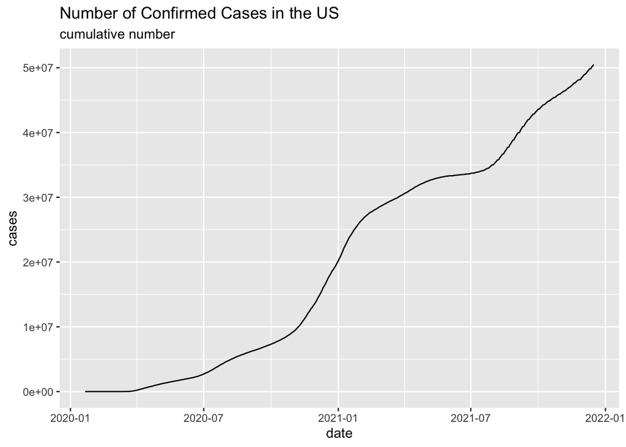

```r
df_nation %>%
  ggplot(mapping = aes(x = date, y = cases)) +
  geom_line()+
  labs(title = "Number of Confirmed Cases in the US",
         subtitle = "cumulative number",
  )
```

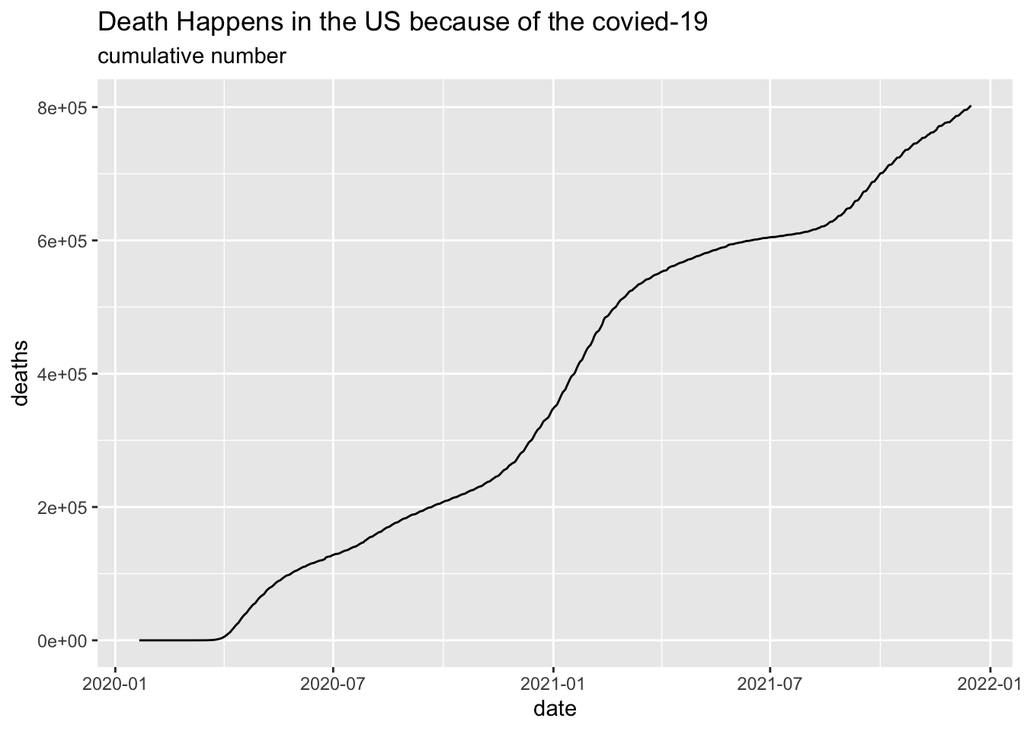

```r
df_nation %>%
  ggplot(mapping = aes(x = date, y = deaths)) +
  geom_line()+
   labs(title = "Death Happens in the US because of the covied-19",
         subtitle = "cumulative number",
  )
```

## Covid-19 situation and Geographic location

We divided the data into four regions based on geographic location, namely Midwest, Northeast, South, West. Because each region contains different number of states and populations, we study the average number of confirmed cases and deaths per 100k people. The time range is from January 2020 to December 2021.

```r
head(df_region)
```

```
## # A tibble: 6 × 7
## # Groups:   date [5]
##   date       region_name cases cases_avg_per_100k deaths deaths_avg_per_100k
##   <date>     <chr>       <dbl>              <dbl>  <dbl>               <dbl>
## 1 2020-01-21 West         0.14                  0      0                   0
## 2 2020-01-22 West         0.14                  0      0                   0
## 3 2020-01-23 West         0.14                  0      0                   0
## 4 2020-01-24 Midwest      0.14                  0      0                   0
## 5 2020-01-24 West         0.14                  0      0                   0
## 6 2020-01-25 Midwest      0.14                  0      0                   0
## # … with 1 more variable: mask_wearing <dbl>
```

[figure not shown]

```r
df_region %>%
  ggplot(mapping = aes(x = date, y = cases_avg_per_100k, color = region_name))+
  geom_line()+
  labs(title = "Number of Deaths in each Region",
         subtitle = "average cases happens per 100k",
  )
```

[figure not shown]

```r
df_region %>%
  ggplot(mapping = aes(x = date, y = deaths_avg_per_100k, color = region_name))+
  geom_line()+
  labs(title = "Number of Deaths in each Region",
         subtitle = "average cases happens per 100k",
  )
```

From the figure, we can see that the Northeast region was initially most affected by the covid-19 virus, and then the Midwest region was affected by the alpha strain in October 2020 much higher than other regions, but the control measures were more effective and the epidemic situation was very fast. Under control. The recent gama strain seems to have a greater impact on the South region. Generally speaking, the control of the epidemic in the western region is relatively stable compared to the other three regions. For the past three months, the situation in Northeast has been good.

In addition, the results obtained by analyzing the two figures above are roughly the same as the results of the overall analysis of the US epidemic. The number of confirmed cases and the number of deaths are positively correlated as a whole. In terms of the daily number of confirmed diagnoses and deaths in the past three months, November to December has a trend of improvement compared with September and October, but compared with the situation in April and May, it is still not optimistic.

## Covid-19 situation and mask_wearing

We draw a scatter plot of the mask wearing rate and the number of confirmed cases.

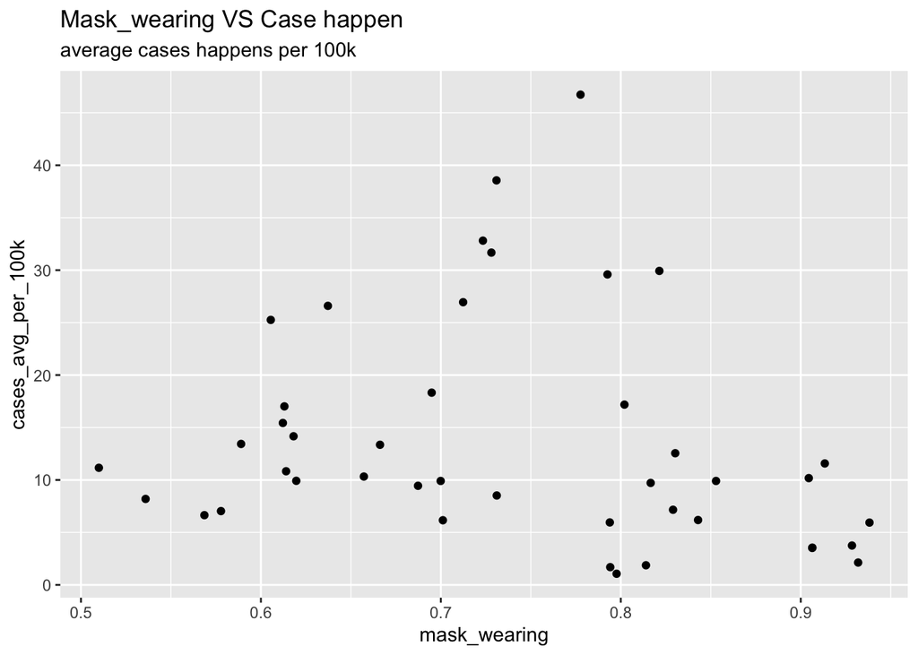

```r
average_mask_wearing_state %>%
  ggplot(mapping = aes(x = mask_wearing, y = cases_avg_per_100k))+
  geom_point() +
  labs(title = "Mask_wearing VS Case happen",
         subtitle = "average cases happens per 100k",
  )
```

# Conclution

# Reference